# STATISTICAL PRED MODELLING - DATA 2204 - 01

#### Feature Importance

```
Feature Importance:
```

```
()
```

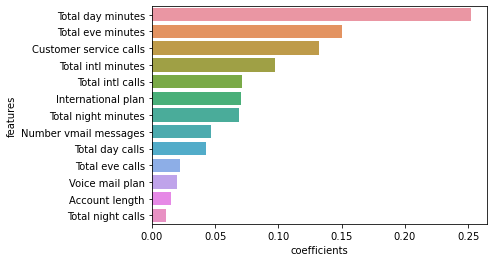

```python
def feature_importance(algo,x_train):
    coefficients = pd.DataFrame(algo.feature_importances_)
    column_df = pd.DataFrame(x_train.columns.tolist())
    coef_sumry = (pd.merge(coefficients, column_df, left_index=True, right_index=True, how="left"))
    coef_sumry.columns = ["coefficients", "features"]
    coef_sumry = coef_sumry.sort_values(by = "coefficients", ascending=False)
    sns.barplot(x="coefficients", y="features", data=coef_sumry)
    return()
print(colored("Feature Importance:", 'blue', attrs=['bold']))
feature_importance(DT,x_train)
```

### Support Vector Machine

```
Classification Report:
              precision    recall  f1-score   support

   Not churn       0.92      0.97      0.94       855
       Churn       0.74      0.50      0.60       145

    accuracy                           0.90      1000
   macro avg       0.83      0.74      0.77      1000
weighted avg       0.89      0.90      0.89      1000

Confusion Matrix:
```

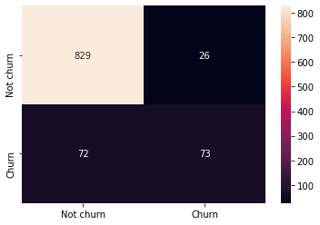

```python
from sklearn.svm import SVC

SVM  = SVC(C=10.0, kernel='rbf', gamma='auto', probability=True, random_state=100)
SVM.fit(x_train,y_train)

y_pred_prob_svm = SVM.predict_proba(x_test)[:,1]
fpr_svm, tpr_svm, thresholds_svm = roc_curve(y_test, SVM.predict(x_test))
roc_auc_svm = auc(fpr_svm, tpr_svm)
precision_svm, recall_svm, th_svm = precision_recall_curve(y_test, SVM.predict(x_test))

print(colored("Classification Report:", 'blue', attrs=['bold']))
print(classification_report(y_test,SVM.predict(x_test),target_names=["Not churn", "Churn"]))
print(colored("Confusion Matrix:", 'blue', attrs=['bold']))
sns.heatmap(
    confusion_matrix(y_test, SVM.predict(x_test)),
    annot=True,
    fmt="d",
    xticklabels=["Not churn", "Churn"],
    yticklabels=["Not churn", "Churn"]
)
```

> Accuracy: 90% of the targets are correctly predicted which is TP and TN.  
> Precision: 74% are deceased out of all the deceased predicted.  
> Recall: 50% are correctly predicted as churn out of actually churned cases.  
> F1 Score: 60% of the churn predictions are correct and it’s significant as the target is imbalanced.

### Performance of the Models over Training Dataset

```python
models = {'Decision Tree': [DT, cols], 'SVM (rbf)': [SVM, cols]}
def model_report(model, training_x, testing_x, training_y, testing_y, name):
    model = model.fit(training_x, training_y)
    predictions = model.predict(testing_x)
    accuracy = accuracy_score(testing_y, predictions)
    recallscore = recall_score(testing_y, predictions)
    precision = precision_score(testing_y, predictions)
    roc_auc = roc_auc_score(testing_y, predictions)
    f1score = f1_score(testing_y, predictions)
    kappa_metric = cohen_kappa_score(testing_y, predictions)

    df = pd.DataFrame({"Model"           : [name],
                       "Accuracy"        : [accuracy],
                       "Recall"          : [recallscore],
                       "Precision"       : [precision],
                       "f1-score"        : [f1score],
                       "Roc_auc"         : [roc_auc],
                       "Kappa_metric"    : [kappa_metric],
                      })
    return df
```

```python
model_performances_train = pd.DataFrame()
for name in models:
    model_performances_train = model_performances_train.append(model_report(models[name][0], x_train[models[name][1]],
                                                                                x_test[models[name][1]],
                                                                                y_train, y_test, name), ignore_index=True)
model_performances_train
```

|  | Model | Accuracy | Recall | Precision | f1-score | Roc_auc | Kappa_metric |
| --- | --- | --- | --- | --- | --- | --- | --- |
| 0 | Decision Tree | 0.910 | 0.668966 | 0.697842 | 0.683099 | 0.809921 | 0.630678 |
| 1 | SVM (rbf) | 0.902 | 0.503448 | 0.737374 | 0.598361 | 0.736519 | 0.544800 |

### Evaluating the performance of the models: ROC Curve

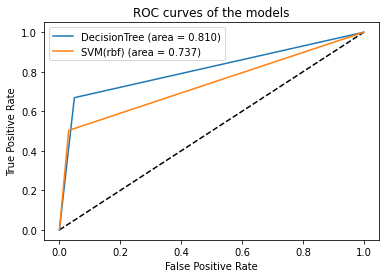

```python
plt.plot([0, 1], [0, 1], 'k--')

plt.plot(fpr_dt, tpr_dt, label='DecisionTree (area = %0.3f)' % roc_auc_dt)
plt.plot(fpr_svm, tpr_svm, label='SVM(rbf) (area = %0.3f)' % roc_auc_svm)

plt.xlabel('False Positive Rate')
plt.ylabel('True Positive Rate')
plt.title('ROC curves of the models')
plt.legend(loc='best')
plt.show()
```

> Curve with the highest area gives the best performance  
> DT Classifier is better than SVM

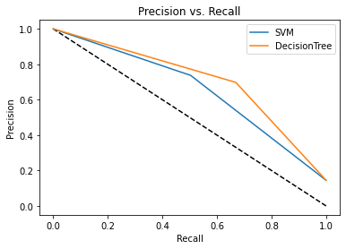

```python
plt.plot([1, 0], [0, 1], 'k--')
plt.plot(recall_svm, precision_svm, label='SVM')
plt.plot(recall_dt, precision_dt, label='DecisionTree')
plt.title('Precision vs. Recall')
plt.xlabel('Recall')
plt.ylabel('Precision')
plt.legend(loc='best')
plt.show()
```

> With higher recall precision goes down

### k-fold Crossvalidation

```python
from sklearn import model_selection
models = []
criterion=['gini', 'entropy']
splitter=['best','random']
max_features=['auto','sqrt','log2']
for c in criterion:
    for s in splitter:
        for m in max_features:
            models.append(('DT '+' '+str(c)+' '+str(s)+' '+str(m),
                           DecisionTreeClassifier(criterion=c,splitter=s,max_features=m,random_state = 100)))
kernel=['linear', 'poly', 'rbf', 'sigmoid']
gamma=['scale', 'auto']
for k in kernel:
    for g in gamma:
        models.append(('SVM '+' '+str(k)+' '+str(g), SVC(C=10,kernel=k,gamma=g,random_state = 100)))
```

#### Evaluating each model in turn

```
DT  gini best auto: 0.612566 (0.055726)
DT  gini best sqrt: 0.612566 (0.055726)
DT  gini best log2: 0.612566 (0.055726)
DT  gini random auto: 0.464417 (0.063054)
DT  gini random sqrt: 0.464417 (0.063054)
DT  gini random log2: 0.464417 (0.063054)
DT  entropy best auto: 0.618930 (0.054463)
DT  entropy best sqrt: 0.618930 (0.054463)
DT  entropy best log2: 0.618930 (0.054463)
DT  entropy random auto: 0.420453 (0.050622)
DT  entropy random sqrt: 0.420453 (0.050622)
DT  entropy random log2: 0.420453 (0.050622)
SVM  linear scale: 0.000000 (0.000000)
SVM  linear auto: 0.000000 (0.000000)
SVM  poly scale: 0.681879 (0.042249)
SVM  poly auto: 0.660242 (0.045072)
SVM  rbf scale: 0.705068 (0.041226)
SVM  rbf auto: 0.703191 (0.044013)
SVM  sigmoid scale: 0.164860 (0.059818)
SVM  sigmoid auto: 0.170162 (0.050540)
```

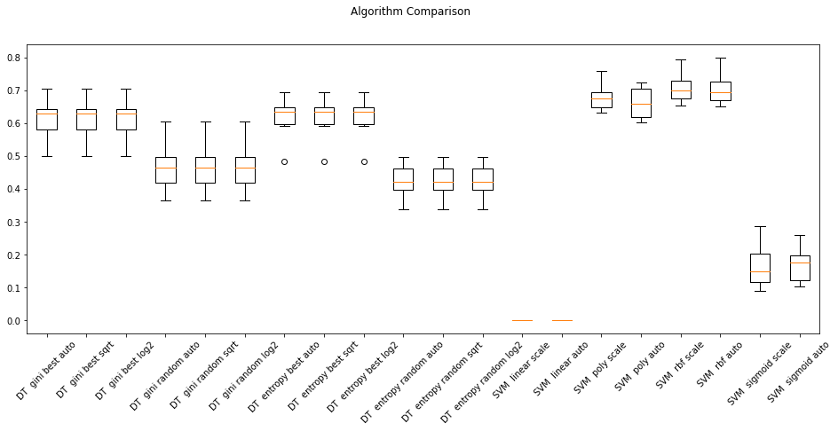

```python
results = []
names = []
scoring = 'f1'
for name, model in models:
    kfold = model_selection.KFold(n_splits=10)
    cv_results = model_selection.cross_val_score(model, df.iloc[:,:13],df['Churn'].to_numpy(), cv=kfold, scoring=scoring)
    results.append(cv_results)
    names.append(name)
    msg = "%s: %f (%f)" % (name, cv_results.mean(), cv_results.std())
    print(msg)

fig = plt.figure(figsize=(16,6))
fig.suptitle('Algorithm Comparison')
ax = fig.add_subplot(111)
plt.boxplot(results)
ax.set_xticklabels(names,rotation=45)
plt.show()
```

> 10 fold validation with scoring with f1-score as our target variable is unbalanced.  
> SVM is more stable than Decision Tree.